# Final Project Visualizations - Draft 1

Kathryn Denning

2/25/2019

# Description of data:

These two datafiles come from the National UFO Reporting Center (http://www.nuforc.org/index.html). One dataset includes all of the reported UFO sightings for January 2019. The other file contains all of the reported UFO sightings in Oregon on record. Both datasets include the following variables: date/time, city, state (though for the Oregon dataset this is all one state), shape (of the reported UFO), duration (of the object’s appearance), summary (description by the reporter), and date posted (when it was posted on the website). A .id column appeared when converting both datafiles into a dataframe, but is not on the website and all datafilesand will be deleted.

# Description of plots

All plots will be made for a general public audience, though the scientific(?) community interested in UFO sightings might also be interested.

### Plot 1A: Choropleth of frequency of reports across US by location

Plot showing the shape of the country with colors changing on the map according to the density of the reports, using changes in color like a heatmap and ideally the viridis color palette. I plan on doing this at the city level within each state, but hopefully can still have the outline of each state visible in the map of the US as well.

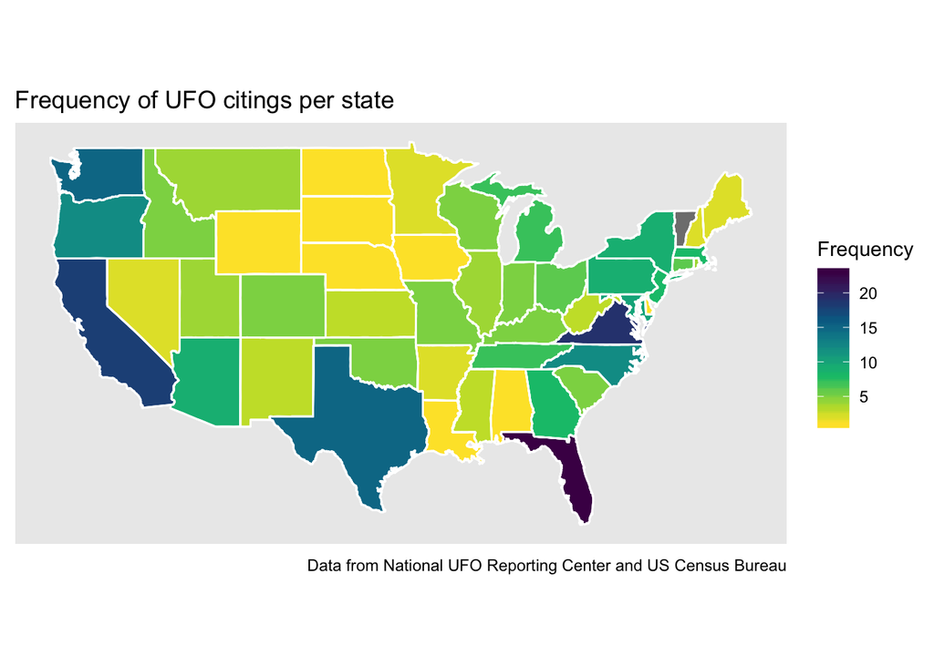

```r
state <- ggplot2::map_data("state")
#need to have a varaible with the full state names in lowercase to merge datasets
state_fullname <- datasets::state.name #calling dataset with state names
state_fullname <- sapply(state.name, tolower) #making them lowercase

state_abbrv <- datasets::state.abb #calling dataset with abbreviations to use as key when merging dataset to get full names in main dataset so that it can be combined with dataset used to make map of US

state_key <- data.frame(
  state_full = state_fullname,
  state_abrv = state_abbrv
) #making dataset with the two character strings state_fullname and state_abbrv

state_key %<>% clean_names

clean %<>%
  mutate(state_abrv = state)

join1 <- left_join(clean, state_key) #joining dataset with fullnames to cleaned ufo dataset
#getting frequency of UFO citings per state
plot1 <- join1 %>%
  group_by(state_full) %>%
  count()

#cleaning dataset that has state information for plot of US so that it can be merged
state_fixed <- state %>%
  mutate(state_full = region) %>%
  select(-region) %>%
  clean_names

#merging data with frequency of UFO with plot dataset
plot1_freq_merged <- left_join(state_fixed, plot1)
#code that removes axes from plot of US
ditch_the_axes <- theme(
  axis.text = element_blank(),
  axis.line = element_blank(),
  axis.ticks = element_blank(),
  panel.border = element_blank(),
  panel.grid = element_blank(),
  axis.title = element_blank()
  )

#code that makes US base
state_base <- ggplot(data = plot1_freq_merged,
                     mapping = aes(x = long, y = lat, group = group)) +
  coord_fixed(1.3) +
  geom_polygon(color = "white", fill = "white")

#code that fills the states with frequency data
state_filled <- state_base +
  geom_polygon(data = plot1_freq_merged, aes(fill = n), color = "white") +
      geom_polygon(color = "white", fill = NA) +
      scale_fill_continuous_sequential("viridis", name = "Frequency") +
  ditch_the_axes

#adding title
state_filled +
  labs(title = "Frequency of UFO citings per state",
       caption = "Data from National UFO Reporting Center and US Census Bureau")
```

After makung the first chloropleth, I decideed the patterns it is showing might be a little misguided, as the frequency of observations seems to be confounded with the populatin size of the state. I decided to re-do the plot to represent the proportion of observations according to the state population.

### Plot 1B: Chloropleth of proportion

```r
#importing dataset with population stats from the United States Census Bureau
pop <- read_csv("nst-est2018-alldata.csv")
```

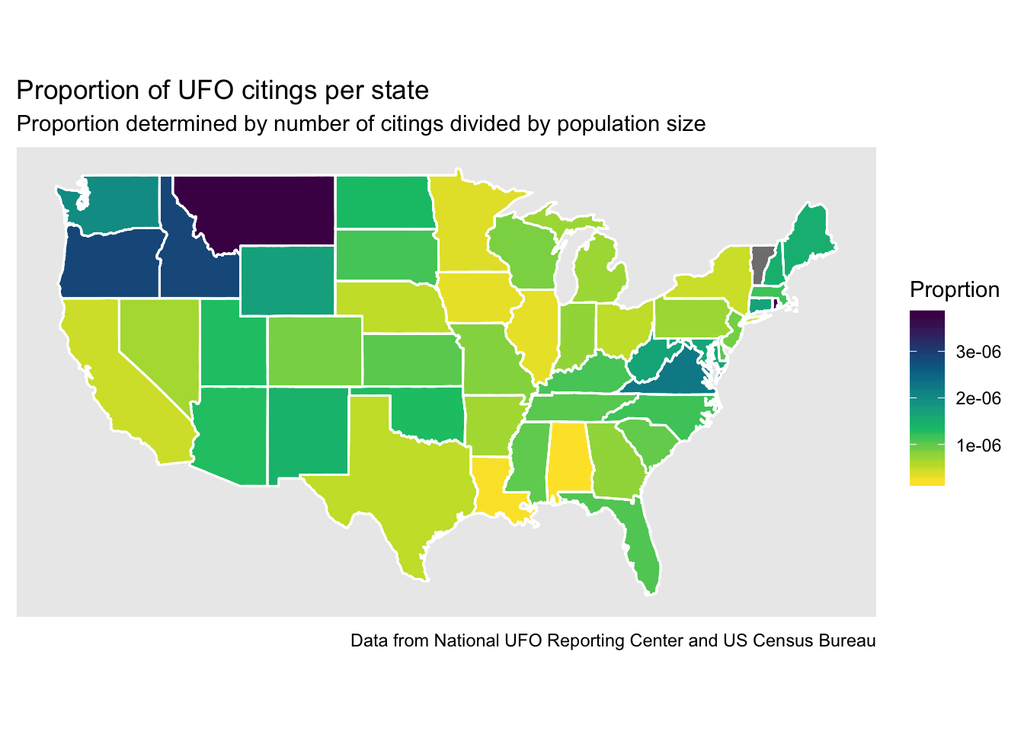

```r
#cleaning the formatting of the names
pop %<>%
  clean_names()

#changing the state name variable so that it will be the same when merging later and making data lowercase
pop$state_full <- tolower(pop$name)

#cleaning dataset to exclude areas that weren't in my UFO dataset
pop %<>%
  filter(state_full != "puerto rico") %>%
  filter(state_full != "district of columbia") %>%
  filter(state_full != "united states")

#making dataset that is only the 50 states, ignoring the four regions for the moment
pop_state <- pop %>%
  filter(state_full != "northeast region") %>%
  filter(state_full != "midwest region") %>%
  filter(state_full != "south region") %>%
  filter(state_full != "west region")

#merging population dataset with the data on the frequency of UFO observations
pop_state_freq_merged <- left_join(pop_state, plot1_freq_merged)
#converting the frequency of observations to be a proportion
freq_bypop_state <- pop_state_freq_merged %>%
  group_by(state_full) %>%
  mutate(freq_bypop = ((n/popestimate2018))) %>%
  summarize(freq_bypop_perstate = mean(freq_bypop))

#adding the proportion back into the main dataset
pop_state_freq_merged1 <- left_join(plot1_freq_merged, freq_bypop_state)
#base of US for the plot
state_base2 <- ggplot(data = pop_state_freq_merged1 , mapping = aes(x = long, y = lat, group = group)) +
  coord_fixed(1.3) +
  geom_polygon(color = "white", fill = "white")

#filling in the states with the proportion data
state_filled2 <- state_base +
  geom_polygon(data = pop_state_freq_merged1 , aes(fill = freq_bypop_perstate), color = "white") +
      geom_polygon(color = "white", fill = NA) +
      scale_fill_continuous_sequential("viridis", name = "Proprtion") +
  ditch_the_axes

#adding labels
state_filled2 +
  labs(title = "Proportion of UFO citings per state",
       subtitle = "Proportion determined by number of citings divided by population size",
       caption = "Data from National UFO Reporting Center and US Census Bureau")
```

I then decided that another way to visualized this information might be to make a barplot showing the frequency of observations by state and region with state organized in descending order in regards to population, to show outlier states with more observations that other states around their same size in population.

### Plot2: Bar plot showing frequency of observations per state with state in descending order by population

```r
#made the population dataset to include a variable of region
pop_region <- pop %>%
  select(c(state_full, popestimate2018, region)) %>%
  filter(state_full != "northeast region") %>%
  filter(state_full != "midwest region") %>%
  filter(state_full != "south region") %>%
  filter(state_full != "west region") %>%
  mutate(region = factor(region, labels = c("Northeast",
                                              "Midwest",
                                              "South",
                                              "West")))


#merged population region dataset with overall dataset with dataset with state names and regions to create key that can merge with the UFO obersevation dataset
region_withfullstate <- left_join(state_key, pop_region)
#merged region data with UFO observation data
pop_freq_state_region <- left_join(region_withfullstate, clean)
```

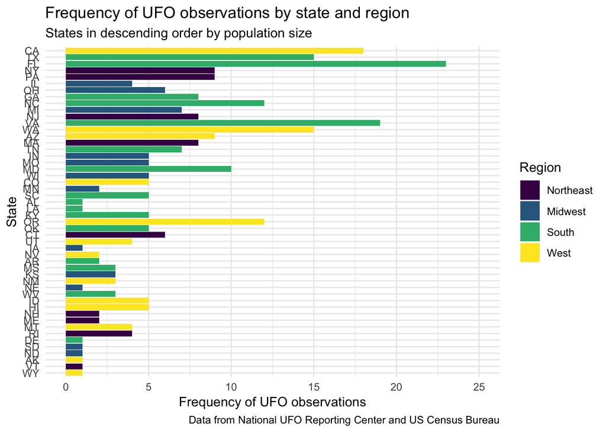

```r
#Make a frequency of observations from this dataset
freq_bystate <- pop_freq_state_region %>%
  group_by(state_abrv) %>%
  count()

#merged the frequency variable back into the overall dataset
plot_freq_bystate_andregion <- left_join(pop_freq_state_region, freq_bystate)
#got rid of variables I didn't want and repeat rows
plot_freq_bystate_andregion2 <- plot_freq_bystate_andregion %>%
  select(state_abrv, popestimate2018, region, n) %>%
  unique()

#bar plot
ggplot(plot_freq_bystate_andregion2, aes(reorder(state_abrv, popestimate2018), n)) +
  geom_col(aes(fill = region)) +
  ylim(0,25) +
  coord_flip() +
  theme_minimal() +
  scale_fill_viridis_d(name = "Region") +
  labs(title = "Frequency of UFO observations by state and region",
       subtitle = "States in descending order by population size",
       y = "Frequency of UFO observations",
       x = "State",
       caption = "Data from National UFO Reporting Center and US Census Bureau")
```

### Plot 3A: Choropleth of frequency of reports across Oregon by location

Plot showing the shape of the state of Oregon with colors changing on the map according to the density of the reports, using changes in color like a heatmap and ideally the viridis color palette. I would like to have either county outlines on the state and cities also identified on the map for reference (like Eugene, Portland, Bend, McMinville (UFO festival location, has to be identified!)).

```r
#cleaning the oregon dataset
ufo_oregon %<>% clean_names()

#importing dataset with information about city, county, and population information
oregon_city_county <- import("oregon_city_county.csv")

#joining dataset of ufo data with oregon city and county data
oregon_join1 <- left_join(oregon_city_county, ufo_oregon)
```

```r
#cleaning new dataset
oregon_join1 %<>%
  na.omit() %>%
  select(-id)

#getting informtion on the lat and long of each county for plotting
county <- ggplot2::map_data("county")

#changing the variables in county to have a key that will match ufo_oregon dataset
oregon_county <- county %>%
  filter(region == "oregon") %>%
  mutate(county = subregion)

oregon_join1$county <- tolower(oregon_join1$county)

#merging the county lat long dataset with the oregon_join1 dataset
oregon_join2 <- left_join(oregon_join1, oregon_county)
#getting the frequency of observations per county
oregon_plot_freq <- oregon_join2 %>%
  group_by(county) %>%
  count()

#joining the frequency back with the main dataset
oregon_join3 <- left_join(oregon_join2, oregon_plot_freq)
#dropping region and subregion from new overall dataset
oregon_join3 %<>%
  select(-c(region, subregion))

#creating the dataset for the state base for the plot
oregon_base <- state_fixed %>%
  filter(state_full == "oregon")

#making the base of oregon for the plot
oregon_base <- ggplot(data = oregon_base,
                     mapping = aes(x = long, y = lat, group = group)) +
  coord_fixed(1.3) +
  geom_polygon(color = "white", fill = "white")

#code that fills oregon with frequency data
oregon_filled <- oregon_base +
  geom_polygon(data = oregon_join3, aes(fill = n), color = "white") +
      geom_polygon(color = "white", fill = NA) +
      scale_fill_continuous_sequential("viridis", name = "Frequency") +
  ditch_the_axes

#adding title
plot_title_freq <- oregon_filled +
  labs(title = "Frequency of UFO citings per county in Oregon",
       subtitle = "Top five counties labeled",
       caption = "Data from National UFO Reporting Center and US Census Bureau")

#figuring out top 5
oregon_join3 %>%
  select(county, n, group) %>%
  arrange(-n) %>%
  unique() %>%
  filter(n > 6693)
```

```
##       county     n group
## 1       lane 23760  2196
## 2  multnomah 15626  2202
## 3     marion 14688  2200
## 4 washington 10752  2210
## 5  clackamas  7650  2179
```

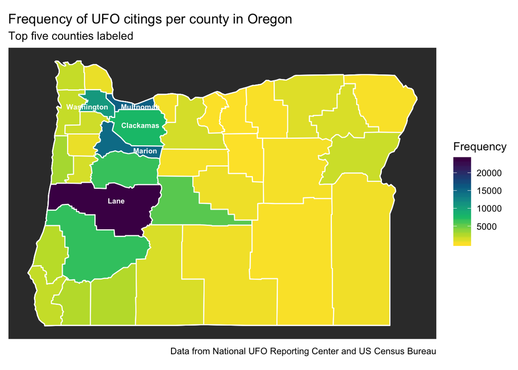

```r
#Adding labels for the top 5 counties
plot_title_freq + theme(panel.background = element_rect(fill = "gray22")) +
  annotate("text",
           label = "Multnomah",
           y = 45.5,
           x = -122.2,
           color = "white",
           size = 2.5,
           fontface = "bold") +
  annotate("text",
           label = "Lane",
           x = -122.7,
           y = 44,
           color = "white",
           size = 2.5,
           fontface = "bold") +
    annotate("text",
           label = "Washington",
           x = -123.3,
           y = 45.5,
           color = "white",
           size = 2.5,
           fontface = "bold") +
    annotate("text",
           label = "Marion",
           x = -122.1,
           y = 44.8,
           color = "white",
           size = 2.5,
           fontface = "bold") +
   annotate("text",
           label = "Clackamas",
           x = -122.2,
           y = 45.2,
           color = "white",
           size = 2.5,
           fontface = "bold")
```

### Plot 3B: Choropleth of proportion of reports across Oregon by location

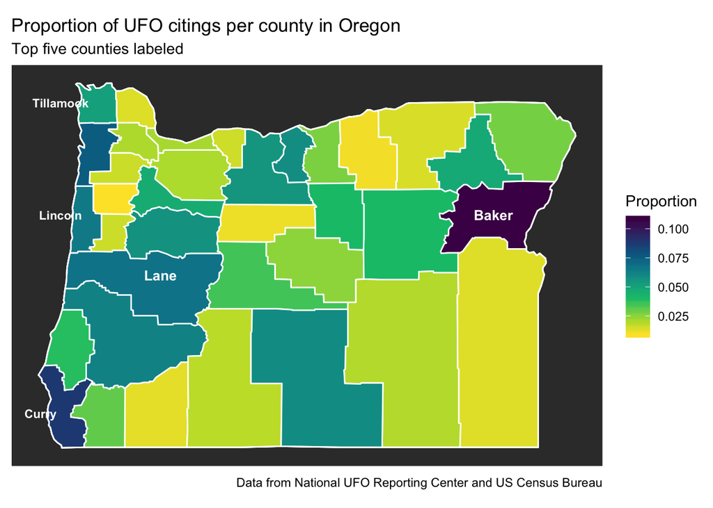

```r
#finding the proportion of observations per county
oregon_plot_proportion <- oregon_join3 %>%
  group_by(county) %>%
  mutate(freq_bypop = (n/county_pop)) %>%
  summarize(freq_bypop_percounty = mean(freq_bypop))

#adding proportion back into overall dataset
oregon_join4 <- left_join(oregon_join3, oregon_plot_proportion)
#filling in base with county proportion information
oregon_filled_pro <- oregon_base +
  geom_polygon(data = oregon_join4, aes(fill = freq_bypop_percounty), color = "white") +
      geom_polygon(color = "white", fill = NA) +
      scale_fill_continuous_sequential("viridis", name = "Proportion") +
  ditch_the_axes

#adding title
plot_title <- oregon_filled_pro +
  labs(title = "Proportion of UFO citings per county in Oregon",
       subtitle = "Top five counties labeled",
       caption = "Data from National UFO Reporting Center and US Census Bureau")

#Figuring out top 5 counties
county_names <- oregon_join4 %>%
  select(county, freq_bypop_percounty, group) %>%
  arrange(-freq_bypop_percounty) %>%
  unique() %>%
  filter(freq_bypop_percounty > 0.06523439)

#Adding labels for the top 5 counties
plot_title +
  theme(panel.background = element_rect(fill = "gray22")) +
  annotate("text",
           label = "Baker",
           y = 44.7,
           x = -117.7,
           color = "white",
           size = 3.5,
           fontface = "bold") +
  annotate("text",
           label = "Lane",
           x = -122.7,
           y = 44,
           color = "white",
           size = 3.5,
           fontface = "bold") +
    annotate("text",
           label = "Curry",
           x = -124.5,
           y = 42.4,
           color = "white",
           size = 3,
           fontface = "bold") +
    annotate("text",
           label = "Tillamook",
           x = -124.2,
           y = 46,
           color = "white",
           size = 3,
           fontface = "bold") +
   annotate("text",
           label = "Lincoln",
           x = -124.2,
           y = 44.7,
           color = "white",
           size = 3,
           fontface = "bold")
```